# Examining socioeconomic disparity in Connecticut school districts

Andrew Ba Tran

May 6, 2016

This is the methodology used behind the story: [Wealth and grades: Compare Connecticut’s school districts](http://trendct.org/2016/05/06/wealth-and-grades-compare-connecticuts-school-districts/).

Visit the [repo](https://github.com/trendct/data/tree/master/2016/05/stanford-cepa) for the data used in this analysis or visit Stanford’s [Center for Education Policy Analysis](https://cepa.stanford.edu/seda/download?nid=1727&destination=node/1717) for even more thorough data sets.

Much of this analysis would not exist without the excellent work from TheUpshot at The New York Times. Their visualization of the data in [Money, Race and Success: How Your School District Compares](http://www.nytimes.com/interactive/2016/04/29/upshot/money-race-and-success-how-your-school-district-compares.html?_r=1) was very inspiring.

What this analysis does:

- Bring in local data from Stanford CEPA (comment out lines to download directly from CEPA)
- Join a couple of their data sets to focus on income, students in grade, and grade score equivalents
- Visualize disparity in Connecticut school districts
- Create a filterable table for all CT school districts
- Visualize disparity in U.S. school districts and surface CT districts

### Loading the packages

```r
library(dplyr)
library(RCurl)
# devtools::install_github("hadley/readxl")
library(readxl)
library(ggplot2)
library(knitr)
library(DT)
```

### Bringing in the data

```r
## District level means in grade equivalent units. There is one observations per district; values are averaged across years, grades and subjects.
# url <- "https://stacks.stanford.edu/file/druid:db586ns4974/district%20means%20grade%20equivalent%20std%20(gs)%20(pooled%20year,%20grade%20and%20sub).xlsx"
# loc.download <- paste0(getwd(), "/data/", "district-means-grade-equivalent-std-gs-pooled-year-grade-and-sub.xlsx")
# download.file(url, loc.download, mode="wb")

grades <- read_excel("data/district-means-grade-equivalent-std-gs-pooled-year-grade-and-sub.xlsx", sheet = 1)
colnames(grades) <- make.names(colnames(grades))

## Subsetting dataframe to just Connecticut schools
# Feel free to switch the CT abbreviation for whatever school you're interested in

ct_grades <- subset(grades, location.state=="CT")
ct_grades_sub <- ct_grades[c("education.agency.name", "average.test.score..math.ela.pooled..in.grade.equiv")]
colnames(ct_grades_sub) <- c("district", "average.grade")
kable(head(ct_grades_sub))
```

| district | average.grade |
| --- | --- |
| UNIFIED SCHOOL DISTRICT #2 | -4.3008 |
| ANDOVER SCHOOL DISTRICT | 1.6717 |
| ANSONIA SCHOOL DISTRICT | -0.3795 |
| AREA COOPERATIVE EDUCATIONAL | -0.4335 |
| ASHFORD SCHOOL DISTRICT | 0.5294 |
| AVON SCHOOL DISTRICT | 2.5961 |

These are estimates of district-level average achievement. Scores of zero mean the district is at the national average. One-unit below zero means that students in the district are one grade level behind the average; one-unit above zero means that students in the district are one grade level above the average.

```r
# District level covariates (socioeconomic, demographic, school level data). There are multiple observations per district; one for each year and grade.
# This is a 500 mb file so expect to sit a round a while

#url <- "https://stacks.stanford.edu/file/druid:db586ns4974/district%20covariates%20by%20year%20and%20grade%20(long%20file).csv"
#loc.download <- paste0(getwd(), "/data/", "district-covariates-by-year-and-grade-long-file.csv")
#download.file(url, loc.download, mode="wb")
soc <- read.csv("data/district-covariates-by-year-and-grade-long-file.csv")

us_grades <- subset(grades, location.state!="CT")

ct_soc <- subset(soc, stateabb=="CT")
ct_soc_6th <- subset(ct_soc, grade==6)
ct_soc_6th_2014 <- subset(ct_soc_6th, year==2014)

ct_6th_income <- ct_soc_6th_2014[c("leaname", "inc50all", "totenrl")]

colnames(ct_6th_income) <- c("district", "median.income", "students.in.grade")
kable(head(ct_6th_income))
```

|  | district | median.income | students.in.grade |
| --- | --- | --- | --- |
| 60321 | ANDOVER SCHOOL DISTRICT | 86817.71 | 46 |
| 60355 | ANSONIA SCHOOL DISTRICT | 60535.68 | 180 |
| 60391 | ASHFORD SCHOOL DISTRICT | 81249.75 | 33 |
| 60427 | AVON SCHOOL DISTRICT | 133213.95 | 288 |
| 60453 | BARKHAMSTED SCHOOL DISTRICT | 104464.11 | 36 |
| 60487 | BERLIN SCHOOL DISTRICT | 101136.31 | 214 |

There are so many other variables to explore in the data set above but we limited it to these two columns. Here’s Stanford’s [Codebook](https://stacks.stanford.edu/file/druid:db586ns4974/codebook_covariates.xlsx).

## Visualizing Connecticut’s educational attainment disparity

```r
ct_scatter <- left_join(ct_6th_income, ct_grades_sub)
```

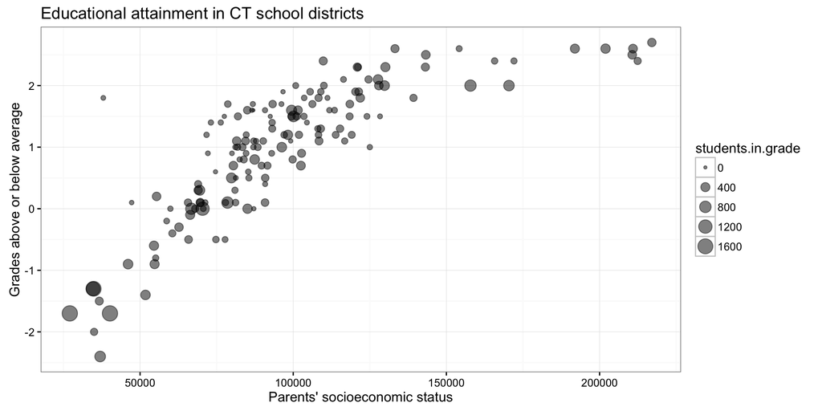

```r
ct_scatter <- subset(ct_scatter, !is.na(average.grade))
ct_scatter <- subset(ct_scatter, !is.na(median.income))

ct_scatter <- ct_scatter[c("district", "median.income", "average.grade", "students.in.grade")]
ct_scatter$average.grade <- round(ct_scatter$average.grade, 1)
ct_scatter$median.income <- round(ct_scatter$median.income, 0)

p <- ggplot(ct_scatter, aes(median.income, average.grade))
p + geom_point(aes(size=students.in.grade), alpha=.5) +
  theme_bw() +
  xlab("Parents' socioeconomic status") + ylab("Grades above or below average") +
  ggtitle("Educational attainment in CT school districts")
```

The scatter plot above shows that the higher the median family income in a school district, the higher the average grade equivalent tends to be.

Students in school districts where families live closer to poverty are, on average, four grade levels behind their counterparts in the wealthiest school districts of Connecticut.

### Explore the data

```r
## district level means in grade equivalent units. There are multiple observations per district; one for each year, grade and subject.
# url <- "https://stacks.stanford.edu/file/druid:db586ns4974/district%20means%20grade%20equivalent%20std%20(gs)%20(separate%20sheets%20year%20and%20grade).xlsx"
# loc.download <- paste0(getwd(), "/data/", "district-means-grade-equivalent-std-gs-separate-sheets-year-and-grade.xlsx")
# download.file(url, loc.download, mode="wb")

grades <- read_excel("data/district-means-grade-equivalent-std-gs-separate-sheets-year-and-grade.xlsx", sheet = 1)

colnames(grades) <- make.names(colnames(grades))
ct_grades2 <- subset(grades, location.state=="CT")
ct_grades2 <- ct_grades2[c("education.agency.name", "Estimated.District.Mean.in.ela..grade.equivalent.std..gs.", "Estimated.District.Mean.in.math..grade.equivalent.std..gs.")]
colnames(ct_grades2) <- c("district", "math", "ela")

ct_scatter_table <- left_join(ct_scatter, ct_grades2)
ct_scatter_table <- ct_scatter_table[c("district", "average.grade", "math", "ela", "median.income", "students.in.grade")]
datatable(ct_scatter_table)
```

|  | district | average.grade | math | ela | median.income | students.in.grade |
| --- | --- | --- | --- | --- | --- | --- |
| 1 | ANDOVER SCHOOL DISTRICT | 1.7 | 4.4259 | 3.9887 | 86818 | 46 |
| 2 | ANSONIA SCHOOL DISTRICT | -0.4 | 2.6529 | 3.2548 | 60536 | 180 |
| 3 | ASHFORD SCHOOL DISTRICT | 0.5 | 3.0081 | 2.0773 | 81250 | 33 |
| 4 | AVON SCHOOL DISTRICT | 2.6 | 5.6295 | 4.4115 | 133214 | 288 |
| 5 | BARKHAMSTED SCHOOL DISTRICT | 1.4 | 3.8677 | 3.9494 | 104464 | 36 |
| 6 | BERLIN SCHOOL DISTRICT | 1.5 | 4.634 | 4.2673 | 101136 | 214 |
| 7 | BETHANY SCHOOL DISTRICT | 1.5 | 5.2051 | 4.6189 | 124062 | 82 |
| 8 | BETHEL SCHOOL DISTRICT | 1.7 | 5.4878 | 5.1157 | 93281 | 213 |
| 9 | BLOOMFIELD SCHOOL DISTRICT | -0.5 | 2.7106 | 2.6398 | 74757 | 133 |
| 10 | BOLTON SCHOOL DISTRICT | 1.6 | 5.0169 | 5.0795 | 90789 | 49 |

[output cut: 141 more lines]

### Visualizing U.S. and CT school districts

```r
us_soc <- subset(soc, stateabb!="CT")
us_soc_6th <- subset(us_soc, grade==6)
us_soc_6th_2014 <- subset(us_soc_6th, year==2014)

us_6th_income <- us_soc_6th_2014[c("leaname", "inc50all", "totenrl")]

us_grades_sub <- us_grades[c("education.agency.name", "average.test.score..math.ela.pooled..in.grade.equiv")]

colnames(us_6th_income) <- c("district", "median.income", "students.in.grade")
colnames(us_grades_sub) <- c("district", "average.grade")

us_scatter <- left_join(us_6th_income, us_grades_sub)
```

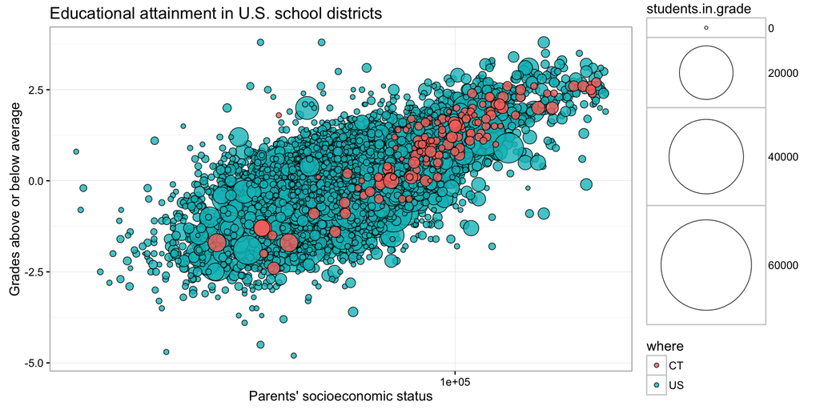

```r
us_scatter <- subset(us_scatter, !is.na(average.grade))
us_scatter <- subset(us_scatter, !is.na(median.income))

us_scatter <- us_scatter[c("district", "median.income", "average.grade", "students.in.grade")]
us_scatter$average.grade <- round(us_scatter$average.grade, 1)
us_scatter$median.income <- round(us_scatter$median.income, 0)


ct_scatter$where <- "CT"
us_scatter$where <- "US"
all_scatter <- rbind(us_scatter, ct_scatter)

ggplot(all_scatter,
       aes(x = median.income, y = average.grade)) + scale_x_log10() +
  geom_point(aes(size = students.in.grade), pch = 21, show.legend = TRUE, alpha=.8) +
  scale_size_continuous(range=c(1,40)) +
  aes(fill = where) + theme_bw() +
  xlab("Parents' socioeconomic status") + ylab("Grades above or below average") +
  ggtitle("Educational attainment in U.S. school districts")
```